# Loon plots and grid graphics

R. Wayne Oldford and Zehao Xu

September 17, 2021

The `loon` package is designed for interactive data exploration. After exploring the events of interest, we need a tool to turn the interactive plots to static ones for publication. Snapshots of interactive `loon` plots can be captured in several ways:

- via a screen shot of the window using `<CTRL-P>` (a primitive rendering of the plot saved as a file)
- via a screen shot of the window from the host operating system (producing a file of several possible types), or
- using `plot()` or `loonGrob()` to translate the plot to a `grid` graphic.

Of these, the last will be most convenient to incorporate plots in `RMarkdown` or to export them using some `R` environments (e.g., `RStudio`). This is the method discussed here.

By translating an interactive `loon` widget into a `grid` object, one can also later edit it to change or add fine details that otherwise might not be easily produced interactively.

See also the vignette “Saving loon plots”

Other packages within the `diveR` package suite are the `loon.ggplot` package and the `loon.shiny` package. These can be used to create elegant `ggplot2` plots from `loon` plots (and incorporate into into `RMArkdown` documents) and to incorporate interactive `loon` plots for a curated exploratory analysis within in a `shiny` app.

# Producing static `grid` plots

The `grid` graphics package is one of the fundamental graphics systems in `R`. It provides a low-level, general purpose graphics system for producing a wide variety of plots. Many well-known graphical systems, e.g. `lattice` and `ggplot2`, use `grid` to draw plots.

Here `loon` plots are transformed into `grid` graphics plots to provide, as close to possible, a *wysiwyg* snapshot of the interactive plot. Being `grid` graphics plots, these in turn can be edited using various `grid` functions.

Begin with a classic data set in R – `mtcars` which contains 32 automobiles and 11 (numeric) variables.

```r
library(loon)
p <- with(mtcars, l_plot(mpg, hp,
                         size = 8,
                         showScales = TRUE))
```

Here, `p` is a `loon` widget. The aesthetics attributes can be accessed either by function `l_cget()` or a simple `[`, as in

```r
# x coordinates
p['x']
```

```
## [1] 21.0 21.0 22.8 21.4 18.7 18.1 14.3 24.4 22.8 19.2 17.8 16.4 17.3
## [14] 15.2 10.4 10.4 14.7 32.4 30.4 33.9 21.5 15.5 15.2 13.3 19.2 27.3
## [27] 26.0 30.4 15.8 19.7 15.0 21.4
```

```r
# point size
p['size']
```

```
## [1] 8 8 8 8 8 8 8 8 8 8 8 8 8 8 8 8 8 8 8 8 8 8 8 8 8 8 8 8 8 8 8 8
```

These returned values always reflect the current states of `p`. For example, suppose the size of points is modified to *6* by direct manipulations on the plot, call `p['size']`, a length 32 vector of *6* is returned. With this handy “querying tool”, all essential elements of a loon widget can be accessed to construct a selfsame `grid` graphics, as in

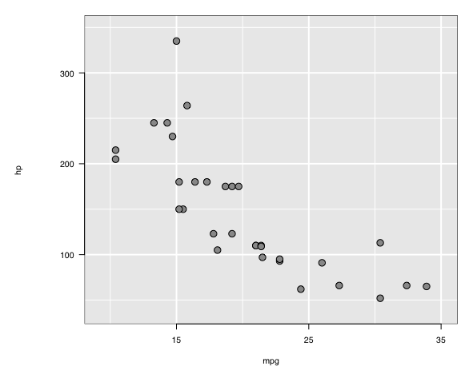

```r
# `p` is a loon widget
plot(p)
```

which produced and printed the plot `p` (as it presently appears) by first translating the `loon` plot into a `grid` graphics object (or `grob`). This can be used at any time, including in an RMarkdown document (as it is here).

For most users, no more need be done. This vignette could end here.  
These users might also be interested in turning `loon` plots into `ggplot`s (and vice versa); if so, some information on this is provided towards the end of this vignette in the `ggplot`s section.

For those interested in a deeper understanding of the `grid` plots, read on.

**Note:** The `plot()` function is simply a wrapper function around the workhorse function `loonGrob()` which does the translatation from current display of the `loon` plot to a `grid` object (or `grob`) capturing the features of the `loon` display. The resulting `grob` is drawn using `grid.draw()` from the `grid` package.

## `loonGrob()`: `loon` –> `grid` object

The `grid` graphic plot is saved by assigning it to a variable when it is created. Either drawing it at the same time (as a side-effect)

```r
g0 <- plot(p)
```

or postponing the drawing to later as in

```r
g0 <- plot(p, draw = FALSE)
```

Either way, a `grid` data structure is created and assigned to the variable `g0`.

Alternatively, `loonGrob()` can be called directly, as in

```r
g0 <- loonGrob(p)
```

This returns a `grid` graphics object or `grob`. It can be drawn at any time using `grid.draw()` from the `grid` package.

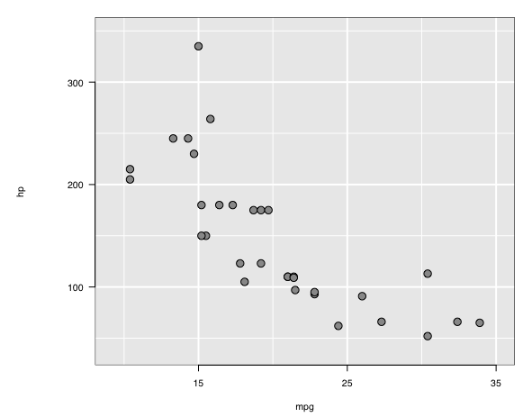

```r
library(grid)
grid.newpage()
grid.draw(g0)
```

## multiple plots

As with any `grob`, the output of `loonGrob()`ccan be manipulated as can `grid` data structure – perhaps arranging several of these into a compound display using `grid.arrange()` (from the `gridExtra` package).

For example, there might be several stages of the interactive plot that ow might be captured. These might be constructed programmatically as

```r
oldColor <- p["color"]
set.seed(3141)
selection <- sample(c(TRUE, FALSE),
                    size = length(oldColor),
                    replace = TRUE)
p["color"]  <- selection
gtrans <- loonGrob(p)
p["active"] <- selection
gauto <- loonGrob(p)
p["active"] <- !selection
gmanual <- loonGrob(p)
p["active"] <- TRUE
p["color"] <- oldColor
```

and then drawn in a single display

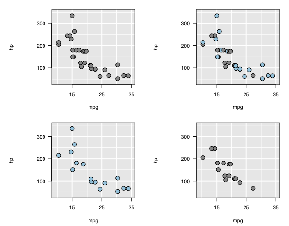

```r
library(gridExtra)
grid.newpage()
grid.arrange(g0, gtrans, gauto, gmanual, nrow = 2)
```

The arrangement itself could have been positioned within another arrrangement.

## the data structure returned by `loonGrob()`

The returned data structure has

```r
class(g0)
```

```
## [1] "gTree" "grob"  "gDesc"
```

This `gTree` object is a tree data structure in `grid` and contains the many `grob`s needed to draw the plot on demand. Numerous functions exist within the `grid` package for validating, drawing, and modifying `grid` graphical objects like this `gTree` and many of its elements.

The tree structure of `g0` is easily seen using `grid.ls()` to list the contents:

```r
grid.ls(g0)
```

```
## GRID.gTree.2
##   l_plot
##     bounding box
##     loon plot
##       guides
##         guides background
##         guidelines: xaxis (major), x = 15
##         guidelines: xaxis (major), x = 25
##         guidelines: xaxis (major), x = 35
##         guidelines: xaxis (minor), x = 10
##         guidelines: xaxis (minor), x = 20
##         guidelines: xaxis (minor), x = 30
##         guidelines: yaxis (major), y = 100
##         guidelines: yaxis (major), y = 200
##         guidelines: yaxis (major), y = 300
##         guidelines: yaxis (minor), y = 50
##         guidelines: yaxis (minor), y = 150
##         guidelines: yaxis (minor), y = 250
##         guidelines: yaxis (minor), y = 350
##       labels
##         x label
##         y label
##         title: textGrob arguments
##       axes
##         x axis
##           major
##           ticks
##           labels
##         y axis
##           major
##           ticks
##           labels
##       clipping region
##       l_plot_layers
##         scatterplot
##           points: primitive glyphs
##       boundary rectangle
```

The levels are indicated by indenting.

The following figure renders the tree structure more generally:

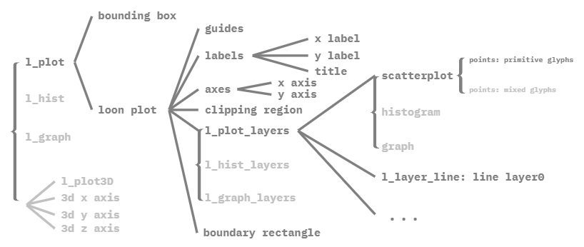

Node labels give the `loonGrob` names with the tree hierarchy following solid lines from left to right. Grey values indicate the same for other types of `loon` plots (separate with braces) and identify potential options peculiar to each `loon` plot.

For example, the root node “l_plot” contains a “bounding box” and a “loon plot”, each loon plot has “guides”, “labels”, “axes”, “clipping region”, “boundary rectangle” and “l_xxxx_layers” (according to the type of loon plot), and the loon plot `p` has “l_plot_layers” consisting of a “scatterplot” and possibly other layers like lines and so on.

## changing a `grid` object: get, edit, set

Knowing the labels, one can retrieve, edit, or even replace any fine details of the static plot. For example, consider the “xlabel” and “ylabel” of the `gTree`. Each label (as it appears above in the list of the `gTree`) provides a path to the corresponding `grob`.

Changes to an existing `grid` plot are made in three steps:

1. `getGrob()` to get a copy of the `grob` to be changed
2. `editGrob()` to produce a `grob` with the desired changes, and
3. `setGrob()` to set the newly produced `grob` into the appropriate place in the plot.

Each of these are now illustrated in turn.

### `getGrob()`

Knowing the path is “x label” in the `gTree` `g0`, the `grob` is extracted using `getGrob()`. For example,

```r
# retrieve xlabel grob
xlabelGrob <- getGrob(g0, "x label")
xlabelGrob
```

```
## text[x label]
```

```r
class(xlabelGrob)
```

```
## [1] "text"  "grob"  "gDesc"
```

which itself has structure:

```r
names(xlabelGrob)
```

```
##  [1] "label"         "x"             "y"             "just"
##  [5] "hjust"         "vjust"         "rot"           "check.overlap"
##  [9] "name"          "gp"            "vp"
```

```r
xlabelGrob$label
```

```
## [1] "mpg"
```

**Note** that `xlabelGrob` is a **copy** of the `grob` found at the “x label” path in `g0`.

Similarly `grob`s at other paths (e.g., “y label”) could be extracted and copied.

**Note** also that some elements of the `gTree` appearing in the listing `grid.ls(g0)` are actually parts of a `grob` and not the path itself. For example, consider the x-axis elements:

```r
xAxisGrob <- getGrob(g0, "x axis")
names(xAxisGrob)
```

[output not shown]

```r
names(xAxisGrob$children)
```

[output not shown]

### `editGrob()`

Having `xlabelGrob` in hand, we can use it to create another copy of it with changed features using `editGrob()`.

For example, a more meaningful `x` axis “label” name can be assigned:

```r
newGrob = editGrob(xlabelGrob,
                   label = "Miles per (US) gallon")
```

The `newGrob` is now a `textGrob`

```r
class(newGrob)
```

```
## [1] "text"  "grob"  "gDesc"
```

with the more informative label:

```r
newGrob$label
```

```
## [1] "Miles per (US) gallon"
```

### `setGrob()`

To complete the change to `g0`, the old “x label” needs to be replaced by `newGrob`:

```r
g0 <- setGrob(gTree = g0,
              gPath = "x label",
              newGrob = newGrob)
```

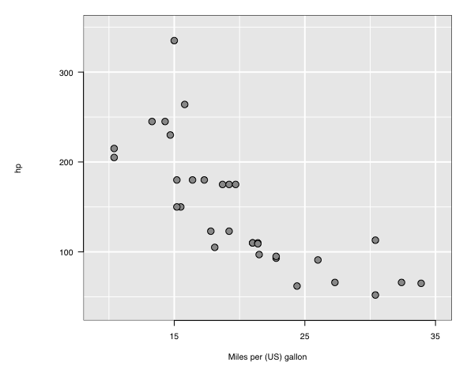

```r
grid.newpage()
grid.draw(g0)
```

In the same way, other features of the “x label” could have been changed as well as the `grob`s at other paths of the `gTree` returned by `loonGrob()`.

## adding an alpha channel to the points

For example, transparency is (presently) missing from `tcltk` colours (on which `loon` is based) – the `tcltk` system presently uses 12 digit hexadecimal colour to represent three channels (one for each of the RGB colours) and no fourth channel indicating alpha transparency. In contrast, transparency is accommodated in `grid` graphics so that one might choose to set the `alpha` values after the transformation.

The points in the plot can be made transparent using `setGrob()`, `editGrob()`, and `getGrob()`, given the path to the points `grob`, namely “points: primitive glyphs”.

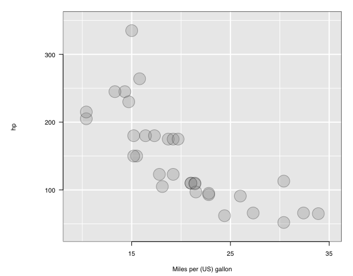

```r
pathGrob <- "points: primitive glyphs"
newLoonPointsGrob <-
  editGrob(
    getGrob(g0, pathGrob),
    gp = gpar(fill = as_hex6color(p['color']),
              col = l_getOption("foreground"),
              fontsize = 20, # give a larger point size,
              alpha = 0.3 # turn color transparent
              )
    )
# update loon points grob
g0 <- setGrob(
  gTree = g0,
  gPath = "points: primitive glyphs",
  newGrob = newLoonPointsGrob
)
grid.newpage()
grid.draw(g0)
```

After modification, the points are now transparent and the size has been made larger.

## helper functions from `loon`

Three `loon` helper functions simplify the some editing of the `gTree` produced by loon in the special case when some `grobs` on the `gTree` are incompletely specified.

The three helper functions are

- `l_instantiateGrob()` which instatiates a complete `grob` using the information available on the incomplete description of the `grob`;
- `l_setGrobPlotView()` which resets the margins of the `grid` plot to those of a `loon` plot when all `labels` and `scales` are shown (or to margin sizes specified in arguments); and
- `l_updateGrob()` which behaves much like `editGrob()` except that it can work with incomplete `grob` descriptions and is called by `l_instantiateGrob()`.

See `help("loonGrobInstantiation")` for more.

Common cases where these functions might be used are when pieces of the plot have been rendered invisible.

### e.g. missing title

The plot `p` was not given a title and no title appears when `g0` is drawn. Nevertheless, the `gTree` of `g0` does appear to have some title information as indicated by the path “title: textGrob arguments”. This is an indication that `loonGrob()` did transfer some title information from `p` to `g0` but that it is incomplete in some way.

If we access the grob at that path, we have

```r
titleGrob <- getGrob(g0, "title: textGrob arguments")
titleGrob$label
```

```
## [1] ""
```

which has an empty label string and, looking at its class:

```r
class(titleGrob)
```

```
## [1] "grob"  "gDesc"
```

appears **not** to be a `text` `grob`. Instead, it is an incomplete description, `gDesc`, of the `grob`.

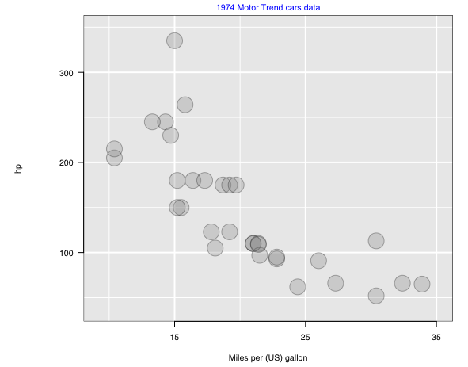

```r
g1 <- l_instantiateGrob(g0, "title: textGrob arguments",
                        label = "1974 Motor Trend cars data",
                        gp = gpar(col = "blue",
                                  fontsize = 8))
grid.newpage()
grid.draw(g1)
```

Note that the fontsize was chosen to be small so that it fit in the space available.

There was too little room for a standard title because the margins of the `loon` plot `p` were smaller with no title. An alternative to making the font small is to return the `loon` (or alternatively some user specified) margins to the plot using `l_setGrobPlotView()`:

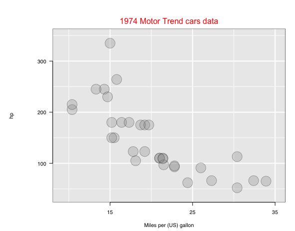

```r
g2 <- l_instantiateGrob(g0, "title: textGrob arguments",
                        label = "1974 Motor Trend cars data",
                        gp = gpar(col = "red"))
g2 <- l_setGrobPlotView(g2)
grid.newpage()
grid.draw(g2)
```

which displays the title in the default fontsize (from translating `p`). The extra room for the title would also admit larger font sizes.

### e.g. missing labels

Oftentimes all labels (i.e., “xlabel”, “ylabel”, and “title”) of `p` will have been turned off when `loonGrob()` was called:

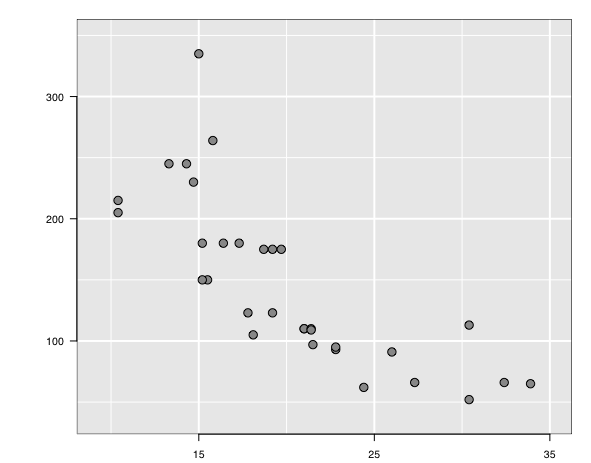

```r
p['showLabels'] <- FALSE
g3 <- loonGrob(p)
grid.newpage()
grid.draw(g3)
```

and we would like to turn these labels on in the static plot.

The `gTree` `g3` now has a different path at each label.

```r
grid.ls(g3)
```

```
## GRID.gTree.5
##   l_plot
##     bounding box
##     loon plot
##       guides
##         guides background
##         guidelines: xaxis (major), x = 15
##         guidelines: xaxis (major), x = 25
##         guidelines: xaxis (major), x = 35
##         guidelines: xaxis (minor), x = 10
##         guidelines: xaxis (minor), x = 20
##         guidelines: xaxis (minor), x = 30
##         guidelines: yaxis (major), y = 100
##         guidelines: yaxis (major), y = 200
##         guidelines: yaxis (major), y = 300
##         guidelines: yaxis (minor), y = 50
##         guidelines: yaxis (minor), y = 150
##         guidelines: yaxis (minor), y = 250
##         guidelines: yaxis (minor), y = 350
##       labels
##         x label: textGrob arguments
##         y label: textGrob arguments
##         title: textGrob arguments
##       axes
##         x axis
##           major
##           ticks
##           labels
##         y axis
##           major
##           ticks
##           labels
##       clipping region
##       l_plot_layers
##         scatterplot
##           points: primitive glyphs
##       boundary rectangle
```

Knowing the paths of the missing labels, the two helper functions (together with the desired`textGrob()` arguments) will construct the desired plot:

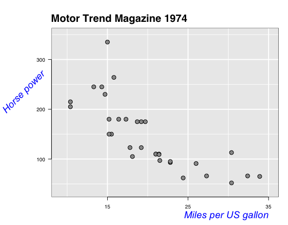

```r
g4 <-l_instantiateGrob(g3,
                       "title: textGrob arguments",
                       x = unit(8, "native"),
                       just = "left",
                       label = "Motor Trend Magazine 1974")

g4 <-l_instantiateGrob(g4,
                       "x label: textGrob arguments",
                       label = "Miles per US gallon",
                       x = unit(35, "native"),
                       y = unit(-1.5, "lines"),
                       just = "right",
                       gp = gpar(fontsize = 15,
                                 fontface = "italic",
                                 col = "blue"))

g4 <-l_instantiateGrob(g4,
                       "y label: textGrob arguments",
                       label = "Horse power",
                       rot = 45,
                       x = unit(7, "native"),
                       y = unit(275, "native"),
                       just = "right",
                       gp = gpar(fontsize = 15,
                                 fontface = "italic",
                                 col = "blue"))

g4 <- l_setGrobPlotView(g4)
grid.newpage()
grid.draw(g4)
```

Extra arguments to `l_instantiateGrob()` are passed on to the `grobFun` (in this case `textGrob()`).

### `l_updateGrob()`

This function is called by `l_instantiateGrob()` to perform the same role as `editGrob()`, but operating on incomplete `grob`s that are only `gDesc`s.

The function `l_updateGrob()` could also be used the same as `editGrob()` on a complete `grob` (e.g. having classes `text`, `grob`, and `gDesc`).

## What if …

### some points are invisible?

Unfortunately, if some points are invisible, their coordinates and aesthetics attributes would be missing in the `loonGrob`. Technically speaking, it is possible to include these invisible points inside the `loonGrob`, however, what stops us doing so is that the data structure would have to be changed – a `pointsGrob` would have to be replaced by a `gTree` with several children `pointsGrob`s to preserve display order and distinguish visible from invisible point.

This solution seems overly complicated and so was not implemented. Better to simply make the changes interactively on the `loon` plot and then translate it again to a new `grid` data structure.

### some points are not primitive glyphs?

`loon` provides non-primitive glyphs, e.g. text glyphs, image glyphs, polygon glyphs, et cetera. Once a non-primitive glyph is drawn, the `grob` label beneath **scatterplot** would be **points: mixed glyph**.

```r
# add text glyph
carNames <- l_glyph_add_text(p, text = rownames(mtcars))
p['glyph'] <- carNames
# loonGrob
g2 <- loonGrob(p)
getGrob(g2, "points: mixed glyphs")
```

It returns a `gTree` object and each child is a `textGrob`.

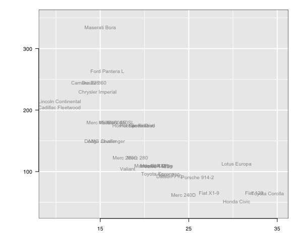

```r
grid.newpage()
grid.draw(g2)
```

# Other packages

## `ggplot`s from `loon.ggplot`

Elegant print graphics are also provided through the popular `ggplot2` package built on top of `grid` graphics. Users familiar with `ggplot2` and its *grammar of graphics* might be interested in the `loon` companion package `loon.ggplot` which extends the grammar to a *grammar of interactive graphics*.

There any `loon` plot can be captured as a `ggplot` by simply calling `loon.ggplot()` on it. The *same* function will also create an interactive `loon` plot if called on an existing `ggplot`.

Details can be found [here](https://great-northern-diver.github.io/loon.ggplot/).

This is probably the simplest solution to have a static plot which can subsequently edited programmatically (via the grammar of `ggplot2`). Any changes to the `ggplot` could also then ve turned into an interactive `loon` plot.

## `shiny` applications from `loon.shiny`

In the interest of supporting reproducible research, analysts will sometimes want to share interactive (and linked) plots in their curated analysis. A `shiny` app is the way to shared this interaction.

The `loon` companion package `loon.shiny` makes it possible to do just that by incorporating interactive `loon` style plots into a `shiny` app. Then the viewer may interactively explore the data under analysis inside an `hyml` browser. The interaction will not be as open ended as using `loon` in `R` but will be peculiar to the data in the app and to the features selected y the author.

The `loon.shiny` transformation relies on the `loon` to `grid` functionality described above. Details can be found [here](https://great-northern-diver.github.io/loon.shiny/).